# Assignment 2

## Trend B

### 1. Loading Data

```r
y <- Y[,5]
# Transform it into a time series
y <- ts(y,frequency=12)
```

### 2. Constructing estimation and hold-out sets

```r
y.tst <- tail(y,12)
y.trn <- head(y,48)
```

### 3. Exploration

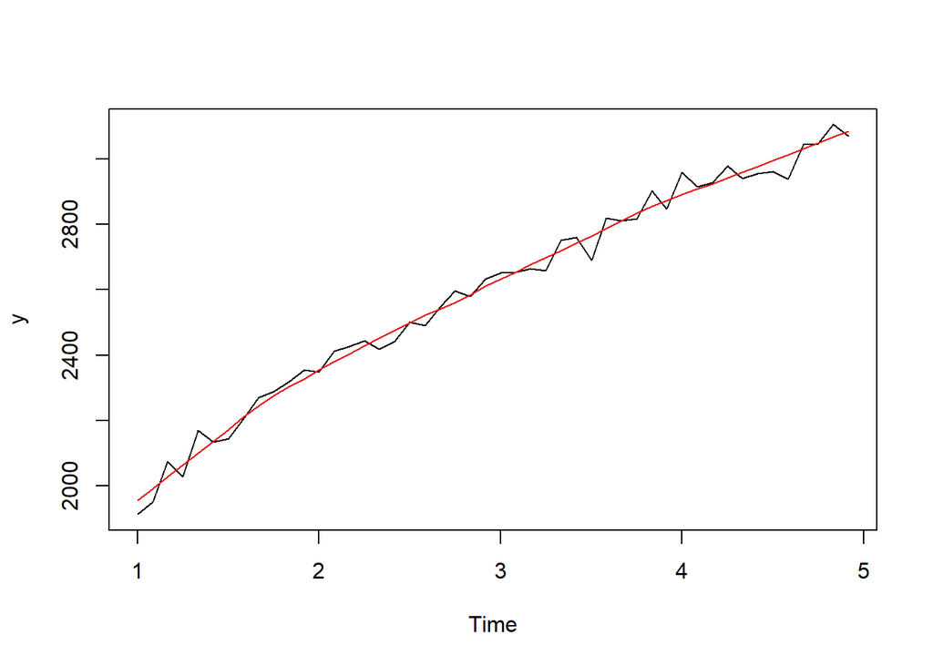

```r
cma <- cmav(y.trn,outplot=1)
```

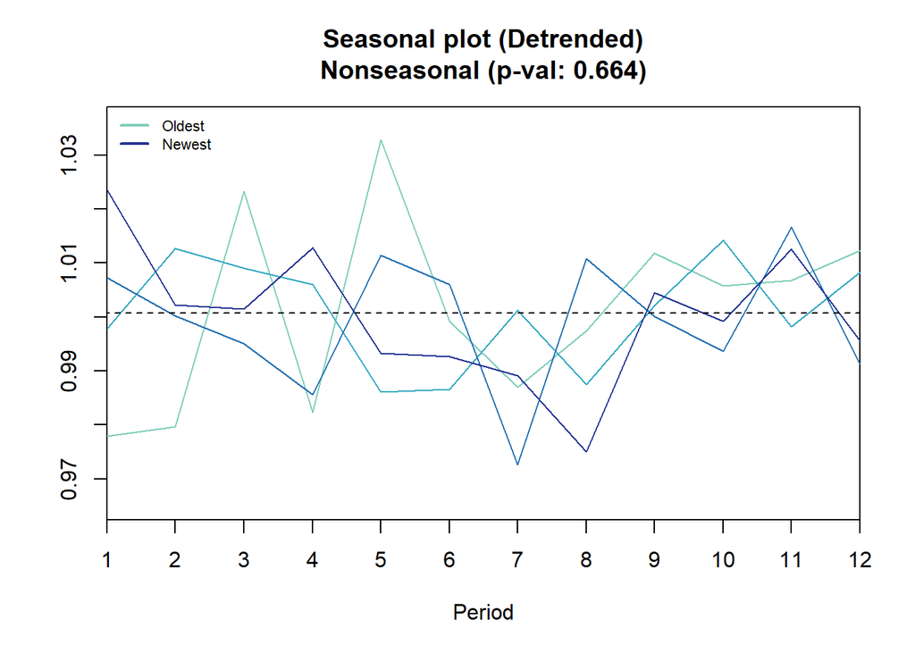

```
## Results of statistical testing
## Evidence of trend: TRUE  (pval: 0)
## Evidence of seasonality: FALSE  (pval: 0.664)
```

```r
seasplot(y.trn)
```

### 4. Forecasting

#### 4.1 Model fitting

```r
# Automatic Alpha ANN
fit <- ets(y.trn,model="ANN")
print(fit)
```

```
## ETS(A,N,N)
##
## Call:
##  ets(y = y.trn, model = "ANN")
##
##   Smoothing parameters:
##     alpha = 0.8439
##
##   Initial states:
##     l = 1920.9275
##
##   sigma:  55.423
##
##      AIC     AICc      BIC
## 575.2143 575.7598 580.8279
```

```r
# Alpha M1 ANN
fit_m1 <- ets(y.trn,model="ANN", alpha = 0.6 )
print(fit_m1)
```

```
## ETS(A,N,N)
##
## Call:
##  ets(y = y.trn, model = "ANN", alpha = 0.6)
##
##   Smoothing parameters:
##     alpha = 0.6
##
##   Initial states:
##     l = 1947.6703
##
##   sigma:  59.2916
##
##      AIC     AICc      BIC
## 579.6917 579.9584 583.4341
```

```r
# Alpha M2 ANN
fit_m2 <- ets(y.trn,model="ANN", alpha = 0.3 )
print(fit_m2)
```

```
## ETS(A,N,N)
##
## Call:
##  ets(y = y.trn, model = "ANN", alpha = 0.3)
##
##   Smoothing parameters:
##     alpha = 0.3
##
##   Initial states:
##     l = 2024.5847
##
##   sigma:  87.7993
##
##      AIC     AICc      BIC
## 617.3800 617.6466 621.1224
```

```r
cirt <- array(NA, c(3, 4), dimnames = list(c("Automatic", "M1", "M2"),
                                         c("MSE", "AIC", "AICc","BIC")))

models <- list(fit, fit_m1, fit_m2)

for (i in 1:3) {
  cirt[i, "MSE"] <- models[[i]]$mse
  cirt[i, "AIC"] <- models[[i]]$aic
  cirt[i, "AICc"] <- models[[i]]$aicc
  cirt[i, "BIC"] <- models[[i]]$bic
}

print(cirt)
```

```
##                MSE      AIC     AICc      BIC
## Automatic 2943.725 575.2143 575.7598 580.8279
## M1        3369.016 579.6917 579.9584 583.4341
## M2        7387.527 617.3800 617.6466 621.1224
```

#### 4.2 Forecasting

- Forecast ANN

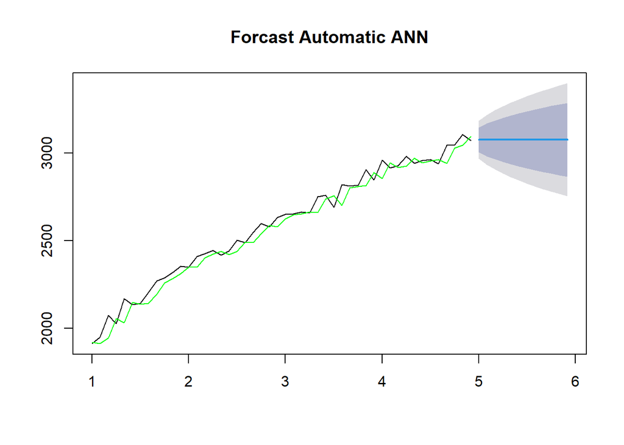

```r
# ploting Automatic ANN
frc <- forecast(fit, h=12)
plot(frc, main = "Forcast Automatic ANN")
lines(fit$fitted,col="green")
```

- Forecast ANN and Alpha M1

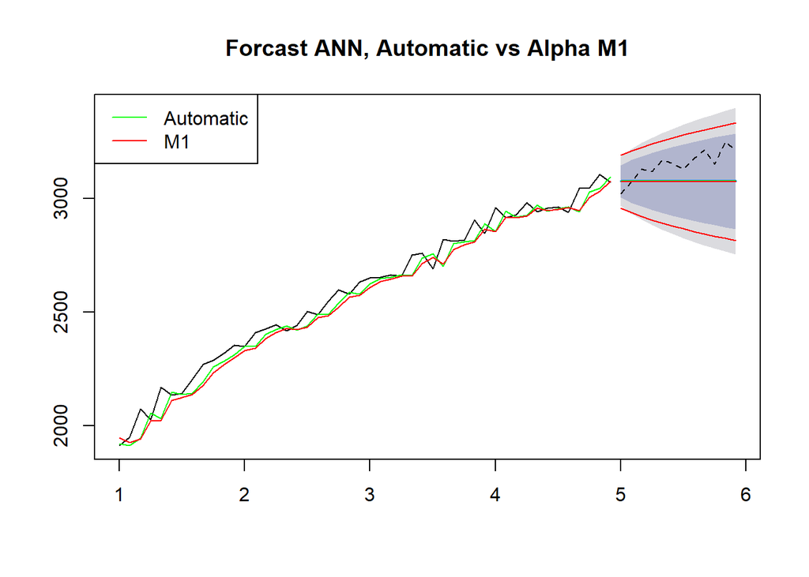

```r
# ploting M1 vs ANN
frc_m1 <- forecast(fit_m1,h=12)
plot(frc, main = "Forcast ANN, Automatic vs Alpha M1")
lines(frc$mean,col="green")
lines(fit$fitted,col="green")
lines(fit_m1$fitted,col="red")

lines(frc_m1$mean,col="red")
lines(frc_m1$lower[,2],col="red") # 95% lower
lines(frc_m1$upper[,2],col="red") # 95% upper
lines(y.tst,lty=2)

# legends
legend("topleft",c("Automatic","M1"),col=c("green","red"),lty=1)
```

- Forecast ANN and Alpha M2

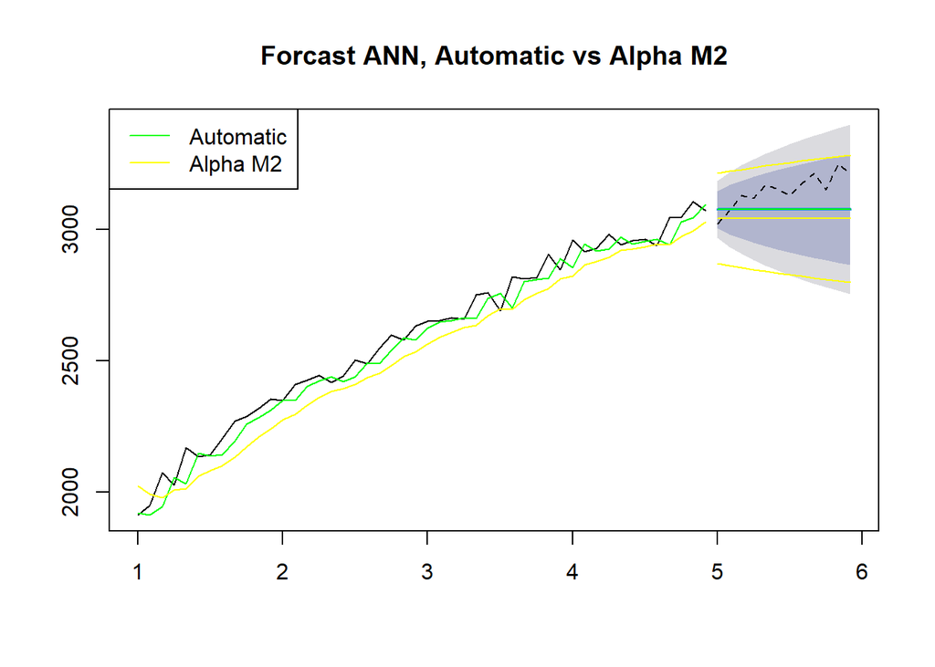

```r
# Ploting M2 vs ANN
frc_m2 <- forecast(fit_m2,h=12)
plot(frc, main = "Forcast ANN, Automatic vs Alpha M2")
lines(frc$mean,col="green")
lines(fit$fitted,col="green")
lines(fit_m2$fitted,col="yellow")

lines(frc_m2$mean,col="yellow")
lines(frc_m2$lower[,2],col="yellow") # 95% lower
lines(frc_m2$upper[,2],col="yellow") # 95% upper
lines(y.tst,lty=2)

# Add legend to the plot
legend("topleft",c("Automatic","Alpha M2"),col=c("green","yellow"),lty=1)
```

- Confidence level ANN, Alpha M1 and Alpha M2

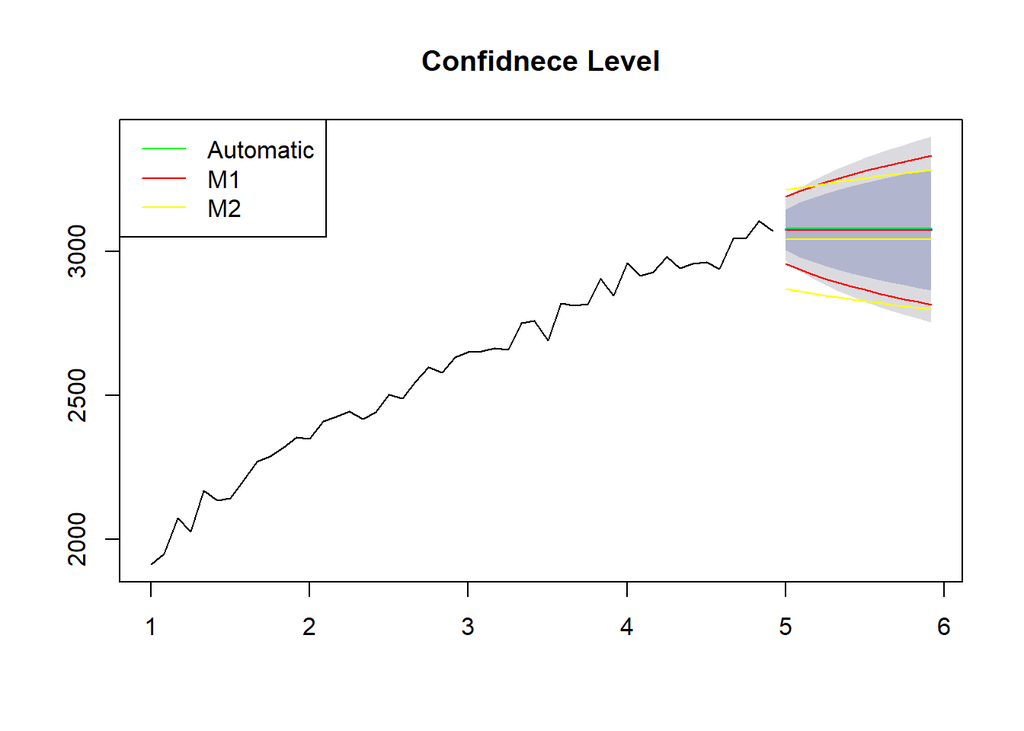

```r
# Ploting confidence level of all 3
plot(frc, main = "Confidnece Level")
lines(frc$mean,col="green")

lines(frc_m1$mean,col="red")
lines(frc_m1$lower[,2],col="red") # 95% lower
lines(frc_m1$upper[,2],col="red")

lines(frc_m2$mean,col="yellow")
lines(frc_m2$lower[,2],col="yellow") # 95% lower
lines(frc_m2$upper[,2],col="yellow") # 95% upper

# Add legend to the plot
legend("topleft",c("Automatic","M1","M2"),col=c("green","red","yellow"),lty=1)
```

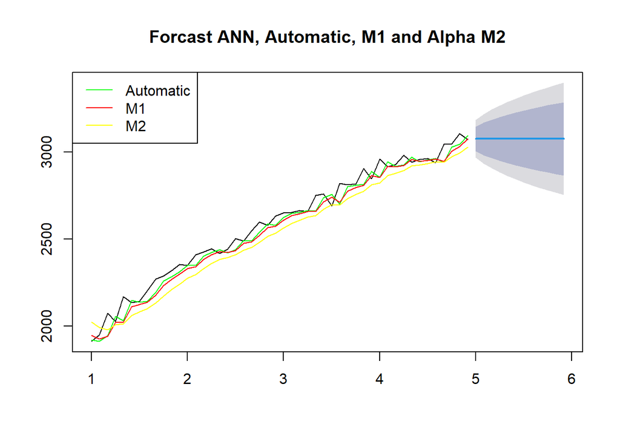

```r
plot(frc, main = "Forcast ANN, Automatic, M1 and Alpha M2")
lines(fit$fitted,col="green")
lines(fit_m1$fitted,col="red")
lines(fit_m2$fitted,col="yellow")
legend("topleft",c("Automatic","M1","M2"),col=c("green","red","yellow"),lty=1)
```

#### 4.3 Model selection

```r
# Function to calculate metrics
calculate_metrics <- function(y, frc) {
  MAE <- mean(abs(y - frc$mean))
  MSE <- mean((y - frc$mean)^2)
  RMSE <- sqrt(MSE)
  return(list(MAE = MAE, MSE = MSE, RMSE = RMSE))
}

# Calculate metrics for different forecasts
metrics_a <- calculate_metrics(y.tst, frc)
metrics_m1 <- calculate_metrics(y.tst, frc_m1)
metrics_m2 <- calculate_metrics(y.tst, frc_m2)

# Create a matrix for the metrics
metrics_matrix <- matrix(c(metrics_a$MAE, metrics_m1$MAE, metrics_m2$MAE,
                           metrics_a$RMSE, metrics_m1$RMSE, metrics_m2$RMSE,
                          metrics_a$MSE, metrics_m1$MSE, metrics_m2$MSE),
                          ncol = 3, byrow = TRUE)

# Add row and column names
rownames(metrics_matrix) <- c("MAE", "MSE", "RMSE")
colnames(metrics_matrix) <- c("Automatic", "Alpha M1", "Alpha M2")

# Display the metrics matrix
metrics_matrix
```

```
##       Automatic   Alpha M1   Alpha M2
## MAE    83.61050   85.05749   111.1186
## MSE    95.35191   97.03912   123.5854
## RMSE 9091.98703 9416.58993 15273.3534
```

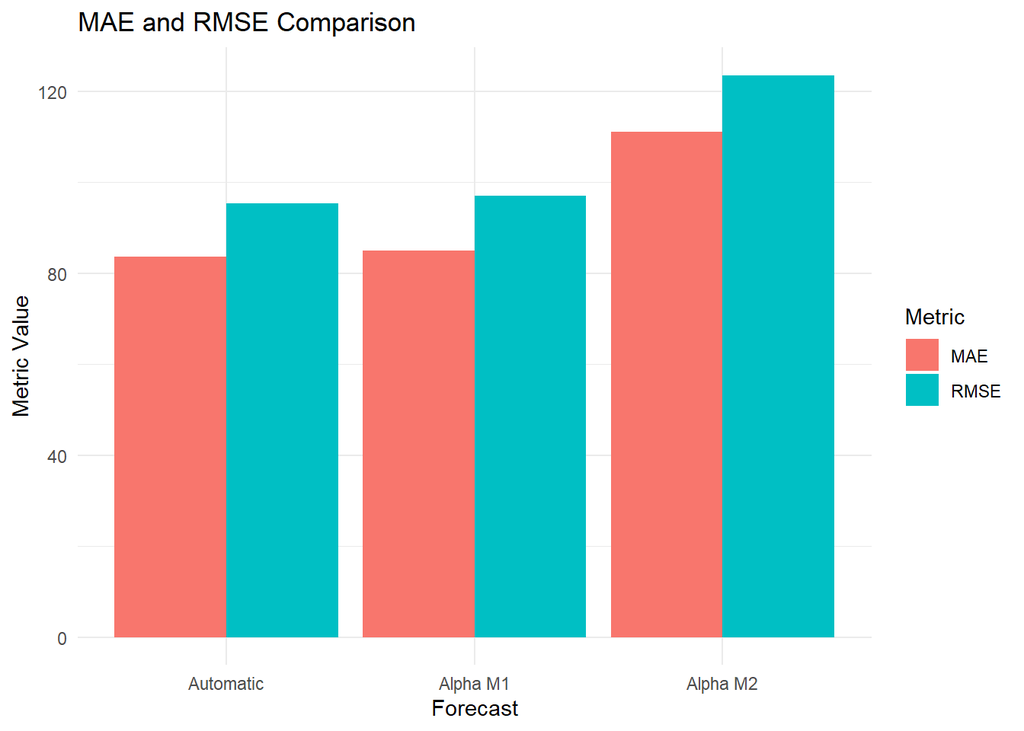

```r
# Create a data frame from the metrics matrix, excluding MSE
metrics_df <- data.frame(
  Metric = rep(c("MAE", "RMSE"), each = 3),
  Value = c(metrics_a$MAE, metrics_m1$MAE, metrics_m2$MAE,
            metrics_a$RMSE, metrics_m1$RMSE, metrics_m2$RMSE),
  Forecast = rep(c("Automatic", "Alpha M1", "Alpha M2"), times = 2)
)
metrics_df$Forecast <- factor(metrics_df$Forecast, levels = c("Automatic", "Alpha M1", "Alpha M2"))

# Create a bar plot
ggplot(metrics_df, aes(x = Forecast, y = Value, fill = Metric)) +
  geom_bar(stat = "identity", position = position_dodge()) +
  labs(title = "MAE and RMSE Comparison",
       y = "Metric Value") +
  theme_minimal()
```

### 5. Answers

- Which one is best using your judgement?

  In the context of modeling the “Trend_B” component within the in-sample data, it is observed that the **Automatic** model offers a good fit to the data. However, it does not effectively filter out noise and outliers. Considering this, the judgment leans toward the automatic model as the preferable choice.
- Which one is best using errors?

  Both error metrics, MSE and AIC, indicate that the **Automatic** model performs the best among the considered models. This suggests that the automatic model provides the most accurate predictions for the “Trend_B” component within the in-sample data.
- Does the selected model perform best in the out-of-sample data?

  In the out-of-sample analysis, the **automatic** model continues to demonstrate its superiority by yielding the best RMSE and MAE values. However, it is important to note that single exponential smoothing, such as the automatic model, may have limitations in modeling time series data with trends.

  It is crucial to recognize that while the automatic model performs well in the current analysis, it may not be the final solution for modeling time series data with trends. More sophisticated models, such as those incorporating trend components explicitly, might be necessary for a more comprehensive modeling approach in certain cases.

## Season A

### 1. Loading Data

```r
y <- Y[,6]
# Transform it into a time series
y <- ts(y,frequency=12)
```

### 2. Constructing estimation and hold-out sets

```r
y.tst <- tail(y,12)
y.trn <- head(y,48)
```

### 3. Exploration

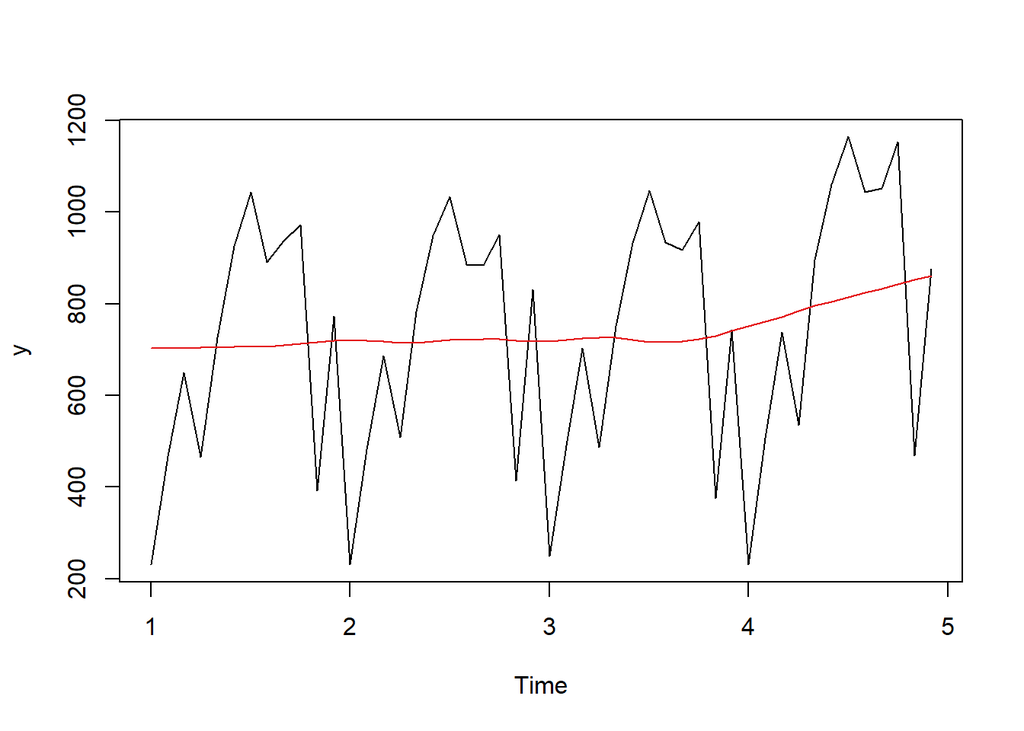

```r
cma <- cmav(y.trn,outplot=1)
```

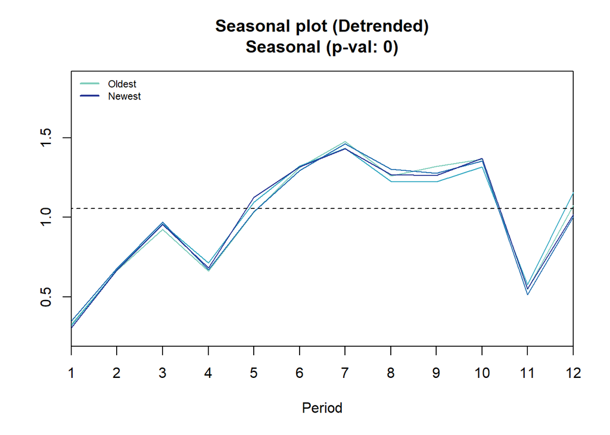

```
## Results of statistical testing
## Evidence of trend: TRUE  (pval: 0)
## Evidence of seasonality: TRUE  (pval: 0)
```

```r
seasplot(y.trn)
```

### 4. Forecasting

#### 4.1 Model fitting

```r
# Automatic Alpha ANN
fit <- ets(y.trn,model="ANN")
print(fit)
```

```
## ETS(A,N,N)
##
## Call:
##  ets(y = y.trn, model = "ANN")
##
##   Smoothing parameters:
##     alpha = 0.5527
##
##   Initial states:
##     l = 371.1084
##
##   sigma:  266.1989
##
##      AIC     AICc      BIC
## 725.8622 726.4076 731.4758
```

```r
# Alpha M1 ANN
fit_m1 <- ets(y.trn,model="ANN", alpha = 0.7 )
print(fit_m1)
```

```
## ETS(A,N,N)
##
## Call:
##  ets(y = y.trn, model = "ANN", alpha = 0.7)
##
##   Smoothing parameters:
##     alpha = 0.7
##
##   Initial states:
##     l = 316.4399
##
##   sigma:  269.9186
##
##      AIC     AICc      BIC
## 725.1943 725.4610 728.9367
```

```r
# Alpha M2 ANN
fit_m2 <- ets(y.trn,model="ANN", alpha = 0.4 )
print(fit_m2)
```

```
## ETS(A,N,N)
##
## Call:
##  ets(y = y.trn, model = "ANN", alpha = 0.4)
##
##   Smoothing parameters:
##     alpha = 0.4
##
##   Initial states:
##     l = 438.6748
##
##   sigma:  269.3941
##
##      AIC     AICc      BIC
## 725.0076 725.2743 728.7500
```

```r
cirt <- array(NA, c(3, 4), dimnames = list(c("Automatic", "M1", "M2"),
                                         c("MSE", "AIC", "AICc","BIC")))

models <- list(fit, fit_m1, fit_m2)

for (i in 1:3) {
  cirt[i, "MSE"] <- models[[i]]$mse
  cirt[i, "AIC"] <- models[[i]]$aic
  cirt[i, "AICc"] <- models[[i]]$aicc
  cirt[i, "BIC"] <- models[[i]]$bic
}

print(cirt)
```

```
##                MSE      AIC     AICc      BIC
## Automatic 67909.28 725.8622 726.4076 731.4758
## M1        69820.37 725.1943 725.4610 728.9367
## M2        69549.29 725.0076 725.2743 728.7500
```

#### 4.2 Forecasting

- Forecast ANN

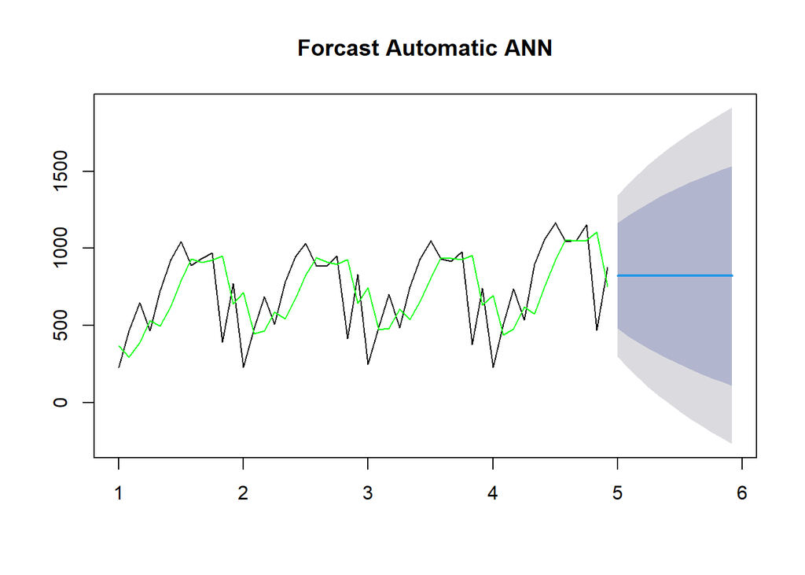

```r
# ploting Automatic ANN
frc <- forecast(fit, h=12)
plot(frc, main = "Forcast Automatic ANN")
lines(fit$fitted,col="green")
```

- Forecast ANN and Alpha M1

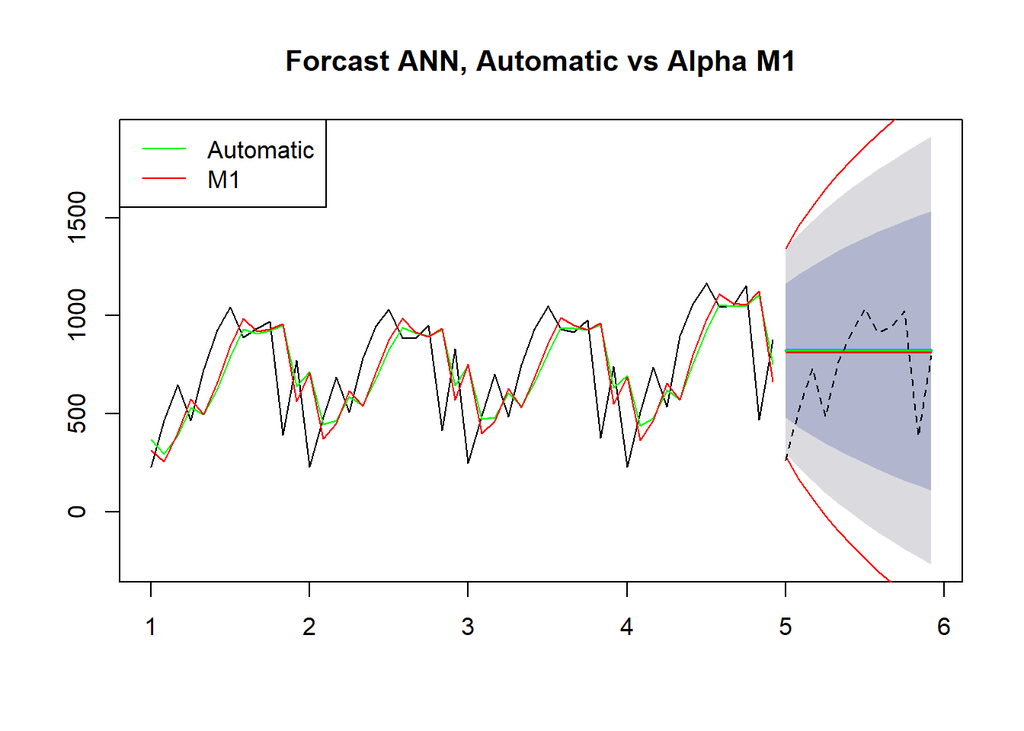

```r
# ploting M1 vs ANN
frc_m1 <- forecast(fit_m1,h=12)
plot(frc, main = "Forcast ANN, Automatic vs Alpha M1")
lines(frc$mean,col="green")
lines(fit$fitted,col="green")
lines(fit_m1$fitted,col="red")

lines(frc_m1$mean,col="red")
lines(frc_m1$lower[,2],col="red") # 95% lower
lines(frc_m1$upper[,2],col="red") # 95% upper
lines(y.tst,lty=2)

# legends
legend("topleft",c("Automatic","M1"),col=c("green","red"),lty=1)
```

- Forecast ANN and Alpha M2

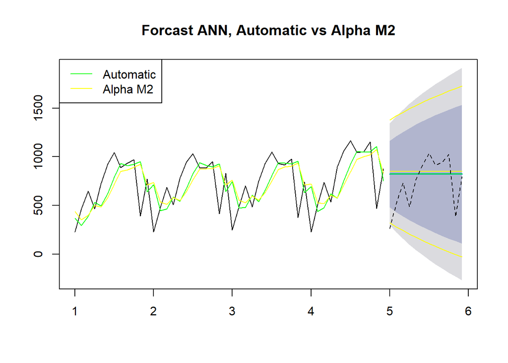

```r
# Ploting M2 vs ANN
frc_m2 <- forecast(fit_m2,h=12)
plot(frc, main = "Forcast ANN, Automatic vs Alpha M2")
lines(frc$mean,col="green")
lines(fit$fitted,col="green")
lines(fit_m2$fitted,col="yellow")

lines(frc_m2$mean,col="yellow")
lines(frc_m2$lower[,2],col="yellow") # 95% lower
lines(frc_m2$upper[,2],col="yellow") # 95% upper
lines(y.tst,lty=2)

# Add legend to the plot
legend("topleft",c("Automatic","Alpha M2"),col=c("green","yellow"),lty=1)
```

- Confidence level ANN, Alpha M1 and Alpha M2

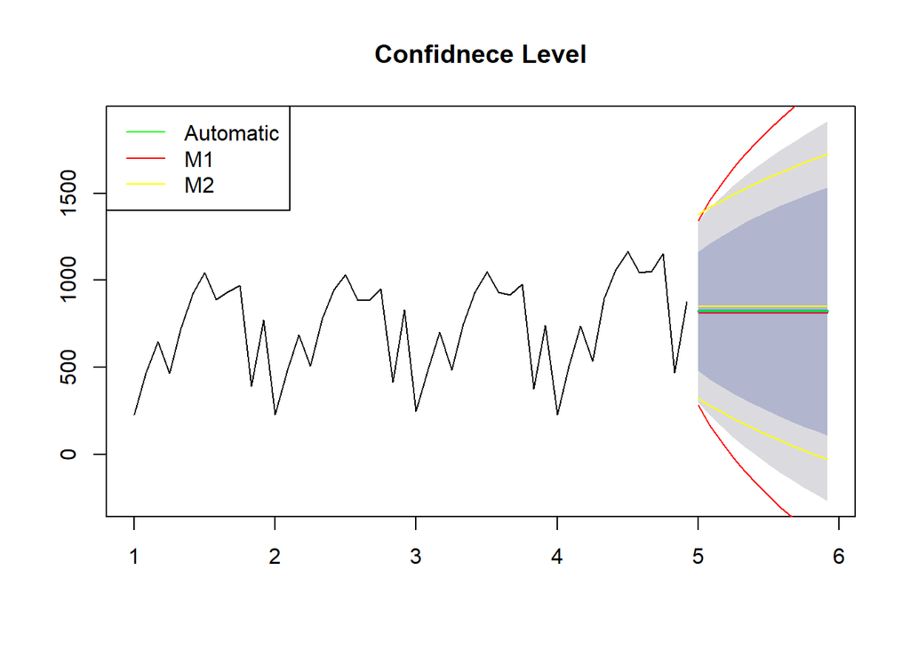

```r
# Ploting confidence level of all 3
plot(frc, main = "Confidnece Level")
lines(frc$mean,col="green")

lines(frc_m1$mean,col="red")
lines(frc_m1$lower[,2],col="red") # 95% lower
lines(frc_m1$upper[,2],col="red")

lines(frc_m2$mean,col="yellow")
lines(frc_m2$lower[,2],col="yellow") # 95% lower
lines(frc_m2$upper[,2],col="yellow") # 95% upper

# Add legend to the plot
legend("topleft",c("Automatic","M1","M2"),col=c("green","red","yellow"),lty=1)
```

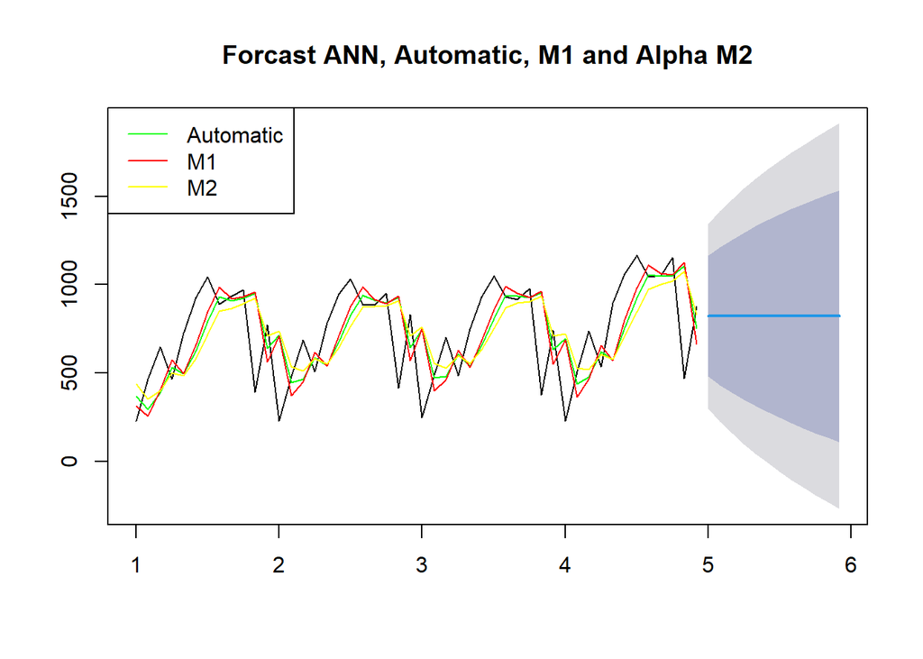

```r
plot(frc, main = "Forcast ANN, Automatic, M1 and Alpha M2")
lines(fit$fitted,col="green")
lines(fit_m1$fitted,col="red")
lines(fit_m2$fitted,col="yellow")
legend("topleft",c("Automatic","M1","M2"),col=c("green","red","yellow"),lty=1)
```